# Clustering Methods

We begin by exploring a data set that exemplifies a consumer segmentation project.

For this example, suppose you work for a subscription-based service (such as cable television or membership in a warehouse club) and have collected data from N = 300 respondents on **age, gender, income, number of children**, whether they **own or rent their homes**, and **whether they currently subscribe to the offered service or not**.

```r
library(cluster)
require(caret)
require(mclust)
library(psych)
library(randomForest)
```

```r
setwd("C:\\Users\\armop\\Dropbox\\PHD\\Teaching\\AGBU505\\2019\\Unsupervised Learning\\Lecture 6")
```

```r
load("seg_df.RData")
```

```r
tail(seg.df)
```

|  | age | gender | income | kids | ownHome | subscribe |
| --- | --- | --- | --- | --- | --- | --- |
| 295 | 36.14964 | Male | 40522.39 | 0 | ownYes | subNo |
| 296 | 32.95227 | Female | 43882.43 | 0 | ownYes | subNo |
| 297 | 40.96255 | Female | 64197.09 | 2 | ownNo | subNo |
| 298 | 38.22980 | Male | 47580.93 | 0 | ownNo | subYes |
| 299 | 33.17036 | Male | 60747.34 | 1 | ownNo | subNo |
| 300 | 34.38388 | Male | 53674.93 | 5 | ownYes | subNo |

```r
summary(seg.df)
```

```
      age           gender        income            kids        ownHome
 Min.   :19.26   Female:157   Min.   : -5183   Min.   :0.00   ownNo :159
 1st Qu.:33.01   Male  :143   1st Qu.: 39656   1st Qu.:0.00   ownYes:141
 Median :39.49                Median : 52014   Median :1.00
 Mean   :41.20                Mean   : 50937   Mean   :1.27
 3rd Qu.:47.90                3rd Qu.: 61403   3rd Qu.:2.00
 Max.   :80.49                Max.   :114278   Max.   :7.00
  subscribe
 subNo :260
 subYes: 40
```

We use the subscription segment data in this chapter for two purposes: **to examine clustering methods that find intrinsic groupings (unsupervised learning)**, and **to show how classification methods learn to predict group membership from known cases (supervised learning).**

Clustering analysis requires two stages: finding a proposed cluster solution and evaluating that solution for one’s business needs. For each method we go through the following steps:

```
• Transform the data if needed for a particular clustering method; for instance,
some methods require all numeric data (e.g., kmeans(), mclust()) or all
categorical data (e.g., poLCA()).

• Compute a distance matrix if needed; some methods require a precomputed
matrix of similarity in order to group observations (e.g., hclust()) .

• Apply the clustering method and save its result to an object. For some methods
this requires specifying the number (K) of groups desired (e.g., kmeans(),
poLCA()).

• For some methods, further parse the object to obtain a solution with K groups
(e.g., hclust()).

• Examine the solution in the model object with regard to the underlying data,
and consider whether it answers a business question.
```

**Recommendation**: Think hard about how you would know whether the solution—assignments of observations to groups—that is proposed by a clustering method is useful for your business problem. Just because some grouping is proposed by an algorithm does not mean that it will help your business.

## Hierarchical Clustering: Basics

The primary information in hierarchical clustering is the distance between observations. There are many ways to compute distance, and we start by examining the best-known method, the Euclidean distance.

A limitation is that Euclidean distance is only defined when observations are **numeric**. In our data *seg.df* it is impossible to compute the distance between Male and Female (a fact many people suspect even before studying statistics). If we did not care about the factor variables, then we could compute Euclidean distance using only the numeric columns.

```r
d <- dist(seg.df[, c("age", "income", "kids")])
```

```r
dist(seg.df[, c("age", "income", "kids")])
```

[output not shown]

[output cut: 17945 more lines]

[output not shown]

```r
head(seg.df)
```

| age | gender | income | kids | ownHome | subscribe |
| --- | --- | --- | --- | --- | --- |
| 47.31613 | Male | 49482.81 | 2 | ownNo | subNo |
| 31.38684 | Male | 35546.29 | 1 | ownYes | subNo |
| 43.20034 | Male | 44169.19 | 0 | ownYes | subNo |
| 37.31700 | Female | 81041.99 | 1 | ownNo | subNo |
| 40.95439 | Female | 79353.01 | 3 | ownYes | subNo |
| 43.03387 | Male | 58143.36 | 4 | ownYes | subNo |

```r
as.matrix(d)[1:6,1:6]
```

|  | 1 | 2 | 3 | 4 | 5 | 6 |
| --- | --- | --- | --- | --- | --- | --- |
| 1 | 0.000 | 13936.531 | 5313.626 | 31559.178 | 29870.205 | 8660.554 |
| 2 | 13936.531 | 0.000 | 8622.906 | 45495.698 | 43806.727 | 22597.078 |
| 3 | 5313.626 | 8622.906 | 0.000 | 36872.800 | 35183.828 | 13974.178 |
| 4 | 31559.178 | 45495.698 | 36872.800 | 0.000 | 1688.977 | 22898.624 |
| 5 | 29870.205 | 43806.727 | 35183.828 | 1688.977 | 0.000 | 21209.651 |
| 6 | 8660.554 | 22597.078 | 13974.178 | 22898.624 | 21209.651 | 0.000 |

For *seg.df* we cannot assume that factor variables are irrelevant to our cluster definitions; it is better to use all the data. The *daisy()* function in the *cluster package* works with mixed data types by rescaling the values, so we use that instead of Euclidean distance:

```r
seg.dist <- daisy(seg.df)
```

```r
as.matrix(seg.dist)[1:6,1:6]
```

|  | 1 | 2 | 3 | 4 | 5 | 6 |
| --- | --- | --- | --- | --- | --- | --- |
| 1 | 0.0000000 | 0.2532815 | 0.2329028 | 0.2617250 | 0.4161338 | 0.2380254 |
| 2 | 0.2532815 | 0.0000000 | 0.0679978 | 0.4129493 | 0.3014468 | 0.1346597 |
| 3 | 0.2329028 | 0.0679978 | 0.0000000 | 0.4246012 | 0.2932957 | 0.1151873 |
| 4 | 0.2617250 | 0.4129493 | 0.4246012 | 0.0000000 | 0.2265436 | 0.4522710 |
| 5 | 0.4161338 | 0.3014468 | 0.2932957 | 0.2265436 | 0.0000000 | 0.2257274 |
| 6 | 0.2380254 | 0.1346597 | 0.1151873 | 0.4522710 | 0.2257274 | 0.0000000 |

The distances look reasonable (zeroes on the diagonal, symmetric, scaled [0, 1]) so we proceed to the hierarchical cluster method itself, invoking hclust() on the dissimilarity matrix:

```r
seg.hc <- hclust(seg.dist, method="complete")
```

We use the complete linkage method, which evaluates the distance between every member when combining observations and groups.

A simple call to plot() will draw the hclust object:

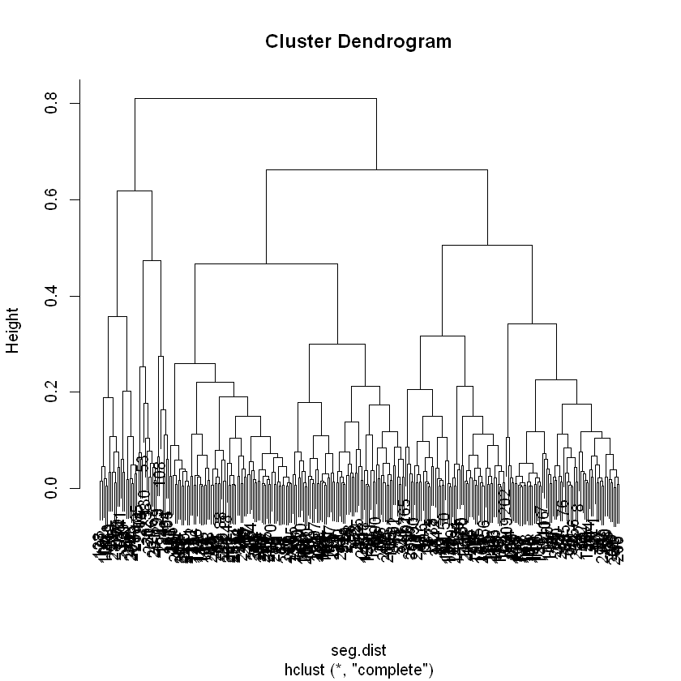

```r
plot(seg.hc)
```

A hierarchical dendrogram is interpreted primarily by height and where observations are joined. The height represents the dissimilarity between elements that are joined. At the lowest level of the tree in figure we see that elements are combined into small groups of 2–10 that are relatively similar, and then those groups are successively combined with less similar groups moving up the tree. The horizontal ordering of branches is not important; branches could exchange places with no change in interpretation.

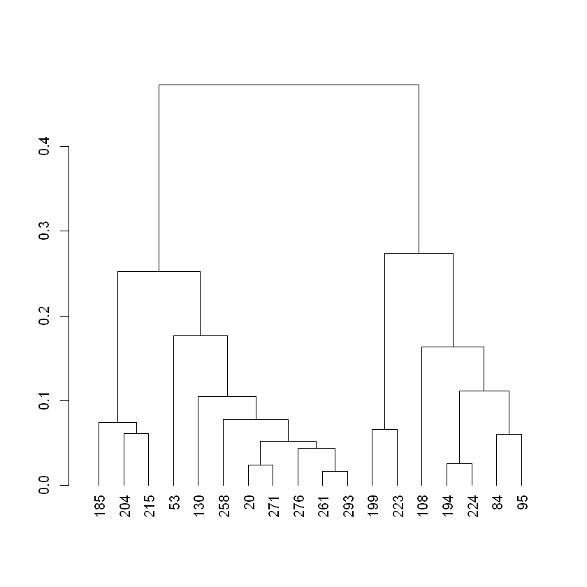

```r
plot(cut(as.dendrogram(seg.hc), h=0.5)$lower[[2]])#$lower[[1]]
```

```r
cut(as.dendrogram(seg.hc), h=0.5)
```

```
$upper
'dendrogram' with 2 branches and 5 members total, at height 0.8111076

$lower
$lower[[1]]
'dendrogram' with 2 branches and 22 members total, at height 0.3573151

$lower[[2]]
'dendrogram' with 2 branches and 18 members total, at height 0.4727599

$lower[[3]]
'dendrogram' with 2 branches and 136 members total, at height 0.4660957

$lower[[4]]
'dendrogram' with 2 branches and 58 members total, at height 0.3162601

$lower[[5]]
'dendrogram' with 2 branches and 66 members total, at height 0.3417087
```

The result is shown in figure above, where we are now able to read the observation labels (which defaults to the row names—usually the row numbers—of observations in the data frame). **Each node at the bottom represents one customer**, and **the brackets show how each has been grouped progressively with other customers**.

```r
seg.df[c(101, 107), ] # similar
```

|  | age | gender | income | kids | ownHome | subscribe |
| --- | --- | --- | --- | --- | --- | --- |
| 101 | 24.73796 | Male | 18457.85 | 1 | ownNo | subYes |
| 107 | 23.19013 | Male | 17510.28 | 1 | ownNo | subYes |

```r
seg.df[c(278, 294), ] # similar
```

|  | age | gender | income | kids | ownHome | subscribe |
| --- | --- | --- | --- | --- | --- | --- |
| 278 | 36.23860 | Female | 46540.88 | 1 | ownNo | subYes |
| 294 | 35.79961 | Female | 52352.69 | 1 | ownNo | subYes |

```r
seg.df[c(173, 141), ] # less similar
```

|  | age | gender | income | kids | ownHome | subscribe |
| --- | --- | --- | --- | --- | --- | --- |
| 173 | 64.70641 | Male | 45517.15 | 0 | ownNo | subYes |
| 141 | 25.17703 | Female | 20125.80 | 2 | ownNo | subYes |

The first two sets—observations that are neighbors in the dendrogram—are similar on all variables (age, gender, income, etc.). The third set—observations taken from widely separated branches—differs substantially on the first four variables.

### Goodness of fit check

Finally, we might check one of the **goodness-of-fit** metrics for a hierarchical cluster solution. One method is the **cophenetic correlation coefficient (CPCC)**, which assesses how well a dendrogram (in this case *seg.hc*) matches the true distance metric (*seg.dist*).

```r
cor(cophenetic(seg.hc), seg.dist)
```

0.768243613231283

*CPCC* is interpreted similarly to *Pearson’s r*. In this case, **CPCC > 0.7** indicates a relatively strong fit, meaning that the hierarchical tree represents the distances between customers well.

### Groups from hclust()

How do we get specific segment assignments? A dendrogram can be cut into clusters at any height desired, resulting in different numbers of groups. For instance, if dendogram is cut at a height of $0.7$, there are $K = 2$ groups (draw a horizontal line at $0.7$ and count how many branches it intersects; each cluster below is a group), while cutting at height of $0.4$ defines $K = 7$ groups.

Because a dendrogram can be cut at any point, the analyst must specify the number of groups desired. We can see where the dendrogram would be cut by overlaying its *plot()* with *rect.hclust()*, specifying the number of groups we want *(k=. . . )*:

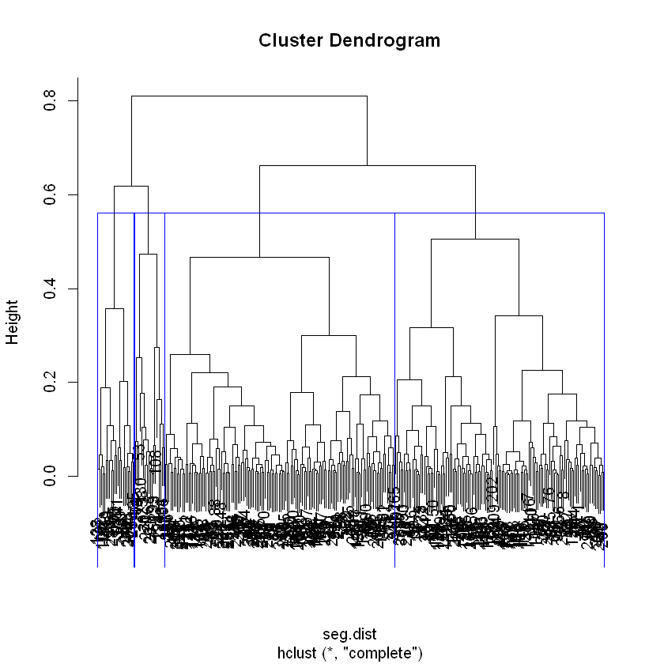

```r
plot(seg.hc)
rect.hclust(seg.hc, k=4, border="blue")
```

We obtain the assignment vector for observations using *cutree()*:

```r
seg.hc.segment <- cutree(seg.hc, k=4) # membership vector for 4 groups
```

```r
table(seg.hc.segment)
```

```
seg.hc.segment
  1   2   3   4
124 136  18  22
```

We see that **groups 1 and 2** dominate the assignment. Note that the class labels $(1, 2, 3, 4)$ are in arbitrary order and are not meaningful in themselves. *seg.hc.segment* is the vector of group assignments.

#### Now we write our own function

A segment inspection function may be complex depending on the business need and might even include plotting as well as data summarization. For purposes here we use a simple function that reports the mean by group. We use mean here instead of a more robust metric such as median because we have several binary variables and mean() easily shows the mixture proportion for them (i.e., 1.5 means a 50% mix of 1 and 2). A very simple function is:

```r
seg.summ <- function(data, groups) {
 aggregate(data, list(groups), function(x) mean(as.numeric(x)))
 }
```

This function first splits the data by reported group (aggregate(. . ., list (groups), . . . )). An anonymous function (function(x) . . . ) then converts all of a group’s data to numeric (as.numeric(x)) and computes its mean().

```r
seg.summ(seg.df, seg.hc.segment)
```

| Group.1 | age | gender | income | kids | ownHome | subscribe |
| --- | --- | --- | --- | --- | --- | --- |
| 1 | 40.78456 | 2.000000 | 49454.08 | 1.314516 | 1.467742 | 1 |
| 2 | 42.03492 | 1.000000 | 53759.62 | 1.235294 | 1.477941 | 1 |
| 3 | 44.31194 | 1.388889 | 52628.42 | 1.388889 | 2.000000 | 2 |
| 4 | 35.82935 | 1.545455 | 40456.14 | 1.136364 | 1.000000 | 2 |

We see that **groups 1 and 2** are distinct from **3 and 4** due to **subscription status**. Among those who do not subscribe, **group 1 is all male** (gender=2 as in levels(seg.df$gender)) while group 2 is all female. Subscribers are differentiated into those who **own a home (group 3)** or **not (group 4)**.

**Important**:Is this interesting from a business point of view? Probably not. Imagine describing the results to a set of executives: “Our advanced hierarchical analysis in R examined consumers who don’t yet subscribe and found two segments to target! The segments are known as ‘Men’ and ‘Women.”’ Such insight is unlikely to win the analyst a promotion.

We confirm this with a quick plot of gender by subscribe with all of the observations colored by segment membership. To do this, we use a trick: we convert the factor variables to numeric, and call the *jitter()* function to add a bit of noise and prevent all the cases from being plotted at the same positions (namely at exactly four points: **(1,1), (1,2), (2,1), and (2,2)**). We color the points by segment with col=seg.hc.segment, and label the axes with more meaningful labels:

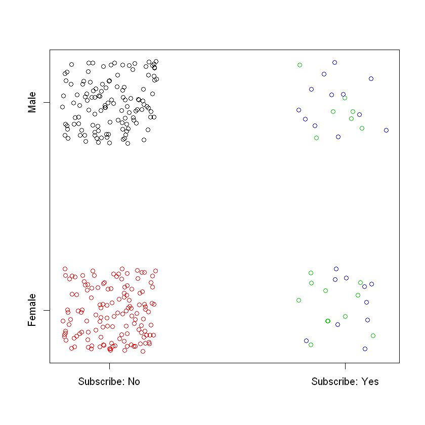

```r
plot(jitter(as.numeric(seg.df$gender)) ∼
 jitter(as.numeric(seg.df$subscribe)),
 col=seg.hc.segment, yaxt="n", xaxt="n", ylab="", xlab="")
axis(1, at=c(1, 2), labels=c("Subscribe: No", "Subscribe: Yes"))
axis(2, at=c(1, 2), labels=levels(seg.df$gender))
```

The resulting plot is shown in figure, where we see clearly that the nonsubscribers are broken into two segments (colored red and black) that are perfectly correlated with gender.

**Note**:Such a plot is a quick hack, which we suggest only for **rapid inspection and debugging purposes**.

**Important**: Why did **hclust()** find a result that is so uninteresting? That may be answered in several ways. For one thing, machine learning techniques often take the path of least resistance and serve up obvious results. In this specific case, the scaling in daisy() rescales variables to [0,1] and this will make two-category factors (gender, subscription status, home ownership) more influential. Overall, this demonstrates why you should expect to try several methods and iterate in order to find something useful.

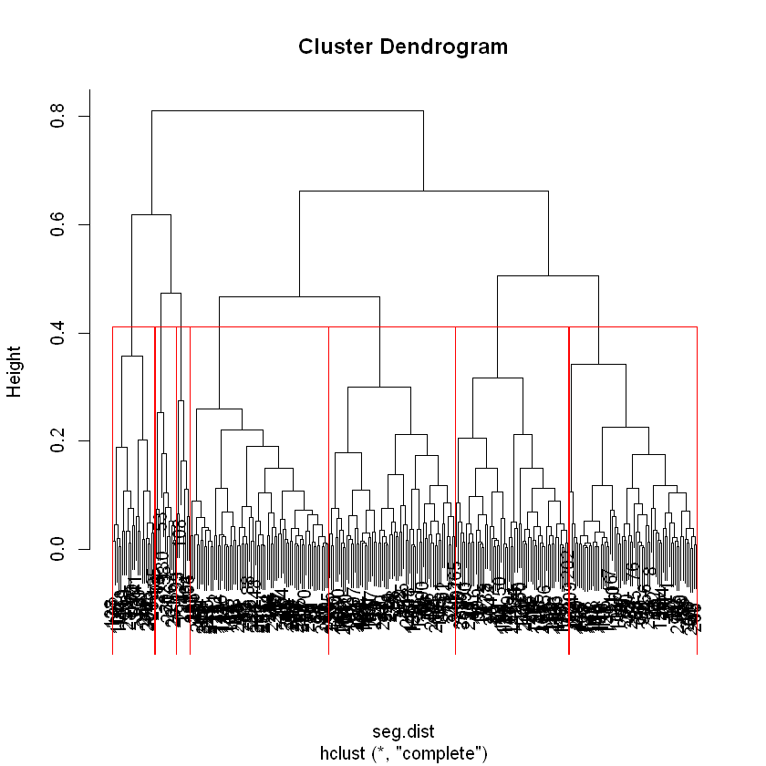

```r
plot(seg.hc)
rect.hclust(seg.hc, k=7, border="red")
```

#### Lets try seven clusters

```r
seg.hc.segment <- cutree(seg.hc, k=7) # membership vector for 4 groups
table(seg.hc.segment)
```

```
seg.hc.segment
 1  2  3  4  5  6  7
66 58 71 65 11 22  7
```

```r
seg.summ(seg.df, seg.hc.segment)
```

| Group.1 | age | gender | income | kids | ownHome | subscribe |
| --- | --- | --- | --- | --- | --- | --- |
| 1 | 36.02187 | 2.000000 | 45227.51 | 1.3484848 | 1 | 1 |
| 2 | 46.20416 | 2.000000 | 54263.61 | 1.2758621 | 2 | 1 |
| 3 | 38.02229 | 1.000000 | 51550.98 | 1.4225352 | 1 | 1 |
| 4 | 46.41795 | 1.000000 | 56172.15 | 1.0307692 | 2 | 1 |
| 5 | 40.95582 | 1.000000 | 52146.57 | 1.7272727 | 2 | 2 |
| 6 | 35.82935 | 1.545455 | 40456.14 | 1.1363636 | 1 | 2 |
| 7 | 49.58583 | 2.000000 | 53385.61 | 0.8571429 | 2 | 2 |

## Mean-Based Clustering: kmeans()

K-means clustering attempts to find groups that are most compact, in terms of the mean sum-of-squares deviation of each observation from the multivariate center (centroid) of its assigned group.

Because it explicitly computes a mean deviation, k-means clustering relies on Euclidean distance. Thus it is only appropriate for numeric data or data that can be reasonably coerced to numeric. In our seg.df data, we have a mix of numeric and binary factors. Unlike higher-order categorical variables, binary factors can be coerced to numeric with no alteration of meaning.

Although it is not optimal to cluster binary values with k-means, given that we have a mixture of binary and numeric data, we might attempt it. Our first step is to create a variant of *seg.df* that is recoded to numeric. We make a copy of *seg.df* and use *ifelse()* to recode the binary factors:

```r
seg.df.num <- seg.df
seg.df.num$gender <- ifelse(seg.df$gender=="Male", 0, 1)
seg.df.num$ownHome <- ifelse(seg.df$ownHome=="ownNo", 0, 1)
seg.df.num$subscribe <- ifelse(seg.df$subscribe=="subNo", 0, 1)
```

```r
summary(seg.df.num)
```

```
      age            gender           income            kids
 Min.   :19.26   Min.   :0.0000   Min.   : -5183   Min.   :0.00
 1st Qu.:33.01   1st Qu.:0.0000   1st Qu.: 39656   1st Qu.:0.00
 Median :39.49   Median :1.0000   Median : 52014   Median :1.00
 Mean   :41.20   Mean   :0.5233   Mean   : 50937   Mean   :1.27
 3rd Qu.:47.90   3rd Qu.:1.0000   3rd Qu.: 61403   3rd Qu.:2.00
 Max.   :80.49   Max.   :1.0000   Max.   :114278   Max.   :7.00
    ownHome       subscribe
 Min.   :0.00   Min.   :0.0000
 1st Qu.:0.00   1st Qu.:0.0000
 Median :0.00   Median :0.0000
 Mean   :0.47   Mean   :0.1333
 3rd Qu.:1.00   3rd Qu.:0.0000
 Max.   :1.00   Max.   :1.0000
```

```r
seg.df.num
```

| age | gender | income | kids | ownHome | subscribe |
| --- | --- | --- | --- | --- | --- |
| 47.31613 | 0 | 49482.81 | 2 | 0 | 0 |
| 31.38684 | 0 | 35546.29 | 1 | 1 | 0 |
| 43.20034 | 0 | 44169.19 | 0 | 1 | 0 |
| 37.31700 | 1 | 81041.99 | 1 | 0 | 0 |
| 40.95439 | 1 | 79353.01 | 3 | 1 | 0 |
| 43.03387 | 0 | 58143.36 | 4 | 1 | 0 |
| 37.55696 | 0 | 19282.23 | 3 | 0 | 0 |
| 28.45129 | 0 | 47245.24 | 0 | 0 | 0 |
| 44.20268 | 1 | 48332.52 | 1 | 0 | 0 |
| 35.15167 | 1 | 52567.89 | 0 | 1 | 0 |
| 47.61097 | 0 | 47917.56 | 0 | 1 | 0 |
| 37.58036 | 1 | 65767.48 | 0 | 0 | 0 |
| 33.21556 | 1 | 69337.66 | 2 | 0 | 0 |
| 43.18109 | 0 | 57200.15 | 3 | 1 | 0 |
| 39.35748 | 0 | 47099.77 | 1 | 1 | 0 |
| 42.03056 | 0 | 57036.84 | 3 | 1 | 0 |
| 41.96189 | 1 | 53127.06 | 0 | 1 | 0 |
| 43.98136 | 1 | 41254.80 | 0 | 1 | 0 |
| 37.61905 | 1 | 63528.47 | 1 | 1 | 0 |
| 32.41215 | 1 | 52649.54 | 2 | 1 | 1 |
| 47.94154 | 1 | 48197.81 | 1 | 1 | 0 |
| 36.70162 | 1 | 46163.38 | 6 | 1 | 0 |
| 30.47705 | 0 | 44151.93 | 2 | 0 | 0 |
| 38.32010 | 1 | 56128.01 | 2 | 1 | 0 |
| 32.72702 | 1 | 62519.89 | 4 | 1 | 0 |
| 40.42549 | 1 | 51195.97 | 1 | 1 | 0 |
| 26.86546 | 0 | 59440.87 | 2 | 0 | 0 |
| 44.50259 | 0 | 57362.59 | 0 | 0 | 0 |
| 35.16896 | 1 | 56112.12 | 1 | 0 | 0 |
| 39.61932 | 1 | 76488.70 | 2 | 0 | 0 |
| ... | ... | ... | ... | ... | ... |
| 32.33691 | 1 | 52776.42 | 1 | 1 | 1 |
| 42.03798 | 1 | 58756.32 | 2 | 0 | 0 |
| 38.87477 | 1 | 44811.78 | 5 | 1 | 0 |
| 40.16990 | 1 | 44125.40 | 4 | 1 | 0 |
| 37.41808 | 1 | 36257.93 | 1 | 0 | 0 |
| 39.14320 | 1 | 45347.01 | 1 | 1 | 1 |
| 29.76301 | 1 | 50720.22 | 0 | 0 | 0 |
| 36.23860 | 1 | 46540.88 | 1 | 0 | 1 |
| 37.24773 | 1 | 50560.17 | 3 | 1 | 0 |
| 37.35856 | 1 | 59663.28 | 1 | 0 | 0 |
| 31.69081 | 1 | 55940.78 | 3 | 0 | 0 |
| 34.03454 | 1 | 66007.99 | 3 | 0 | 0 |
| 36.89752 | 1 | 39366.95 | 1 | 0 | 1 |
| 38.16915 | 1 | 54509.25 | 2 | 0 | 0 |
| 42.37342 | 1 | 49308.97 | 2 | 0 | 0 |
| 40.30668 | 1 | 54740.28 | 0 | 1 | 0 |
| 36.24118 | 0 | 49775.29 | 1 | 0 | 1 |
| 35.82586 | 1 | 41766.29 | 2 | 0 | 1 |
| 26.40436 | 1 | 73240.62 | 2 | 0 | 0 |
| 42.40763 | 0 | 53520.36 | 1 | 0 | 0 |
| 35.88063 | 0 | 66423.74 | 1 | 0 | 0 |
| 36.22989 | 1 | 41192.28 | 4 | 0 | 0 |
| 39.54330 | 1 | 58933.34 | 2 | 1 | 1 |
| 35.79961 | 1 | 52352.69 | 1 | 0 | 1 |
| 36.14964 | 0 | 40522.39 | 0 | 1 | 0 |
| 32.95227 | 1 | 43882.43 | 0 | 1 | 0 |
| 40.96255 | 1 | 64197.09 | 2 | 0 | 0 |
| 38.22980 | 0 | 47580.93 | 0 | 0 | 1 |
| 33.17036 | 0 | 60747.34 | 1 | 0 | 0 |
| 34.38388 | 0 | 53674.93 | 5 | 1 | 0 |

We now run the kmeans() algorithm, which specifically requires specifying the number of clusters to find. We ask for four clusters with centers=4:

```r
set.seed(96743)
seg.k <- kmeans(seg.df.num, centers=4)
```

We use our custom function seg.summ() to do a quick check of the data by proposed group, where cluster assignments are found in the $cluster vector inside the seg.k model:

```r
seg.summ(seg.df, seg.k$cluster)
```

| Group.1 | age | gender | income | kids | ownHome | subscribe |
| --- | --- | --- | --- | --- | --- | --- |
| 1 | 56.37245 | 1.428571 | 92287.07 | 0.4285714 | 1.857143 | 1.142857 |
| 2 | 29.58704 | 1.571429 | 21631.79 | 1.0634921 | 1.301587 | 1.158730 |
| 3 | 44.42051 | 1.452632 | 64703.76 | 1.2947368 | 1.421053 | 1.073684 |
| 4 | 42.08381 | 1.454545 | 48208.86 | 1.5041322 | 1.528926 | 1.165289 |

Unlike with hclust() we now see some interesting differences; the groups appear to vary by age, gender, kids, income, and home ownership. For example, we can visually check the distribution of income according to segment (which kmeans() stored in seg.k$cluster) using boxplot():

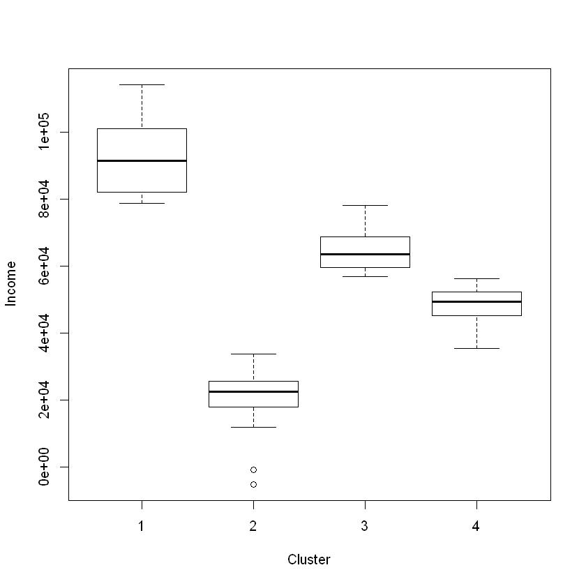

```r
boxplot(seg.df.num$income ∼ seg.k$cluster, ylab="Income", xlab="Cluster")
```

The result is figure, which shows substantial differences in income by segment.

**Note** that in clustering models, the group labels are in arbitrary order, so don’t worry if your solution shows the same pattern with different labels.

We visualize the clusters by plotting them against a dimensional plot. *clusplot()* will perform dimensional reduction with principal components or multidimensional scaling as the data warrant, and then plot the observations with cluster membership identified

We use *clusplot* from the cluster package with arguments to *color* the groups, *shade* the ellipses for group membership, label only the groups (not the individual points) with *labels=4*, and omit distance lines between groups *"(lines=0)*:

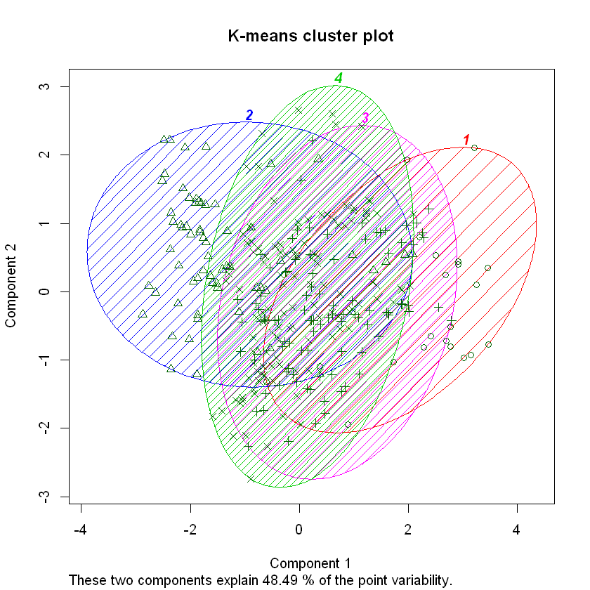

```r
clusplot(seg.df, seg.k$cluster, color=TRUE, shade=TRUE,labels=4, lines=0, main="K-means cluster plot")
```

The code produces the plot in figure, which plots cluster assignment by color and ellipses against the first two principal components of the predictors (See last lecture) . **Groups 3 and 4 are largely overlapping** (in this dimensional reduction) while **group 1** and especially **group 2** are modestly differentiated.

Overall, this is a far more interesting cluster solution for our segmentation data than the hclust() proposal. The groups here are clearly differentiated on key variables such as age and income.

This may suggest a business strategy. In the present case, for instance, we see that **group 1 is modestly well differentiated, and has the highest average income. That may make it a good target for a potential campaign.** Many other strategies are possible, too; the key point is that the analysis provides interesting options to consider.

#### Repeat for 3 clusters

```r
set.seed(96743)
seg.k <- kmeans(seg.df.num, centers=3)
```

```r
seg.summ(seg.df, seg.k$cluster)
```

| Group.1 | age | gender | income | kids | ownHome | subscribe |
| --- | --- | --- | --- | --- | --- | --- |
| 1 | 49.10841 | 1.360656 | 78160.35 | 0.9508197 | 1.540984 | 1.081967 |
| 2 | 31.29751 | 1.571429 | 23147.31 | 0.9857143 | 1.328571 | 1.157143 |
| 3 | 42.44649 | 1.479290 | 52620.52 | 1.5029586 | 1.502959 | 1.142012 |

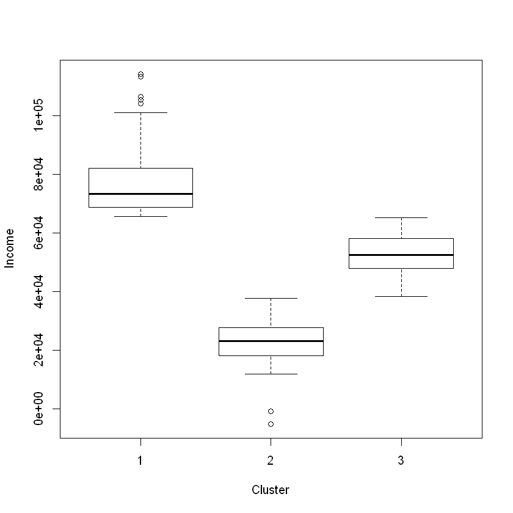

```r
boxplot(seg.df.num$income ∼ seg.k$cluster, ylab="Income", xlab="Cluster")
```

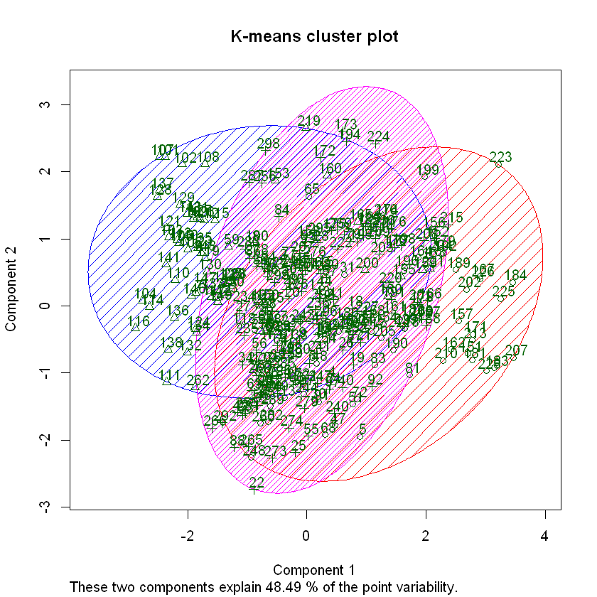

```r
clusplot(seg.df, seg.k$cluster, color=TRUE, shade=TRUE,labels=3, lines=0, main="K-means cluster plot")
```

# Repeat for 5 clusters

| Group.1 | age | gender | income | kids | ownHome | subscribe |
| --- | --- | --- | --- | --- | --- | --- |
| 1 | 57.01495 | 1.500000 | 98230.22 | 0.2857143 | 1.857143 | 1.000000 |
| 2 | 42.70781 | 1.462500 | 45234.25 | 1.3625000 | 1.550000 | 1.175000 |
| 3 | 46.60014 | 1.333333 | 71618.19 | 1.0980392 | 1.431373 | 1.098039 |
| 4 | 42.23181 | 1.505376 | 57049.21 | 1.5913978 | 1.473118 | 1.118280 |
| 5 | 29.69186 | 1.564516 | 21433.76 | 1.0322581 | 1.306452 | 1.161290 |

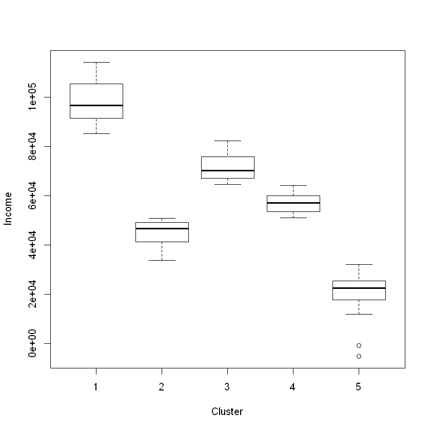

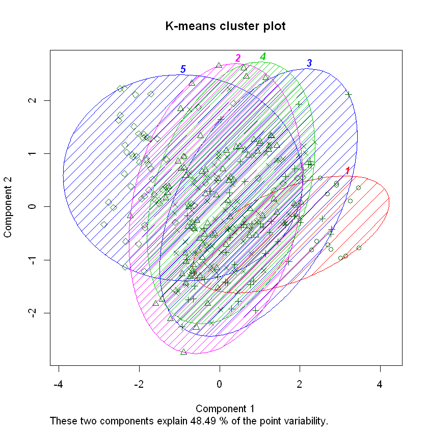

```r
set.seed(96743)
seg.k <- kmeans(seg.df.num, centers=5)
seg.summ(seg.df, seg.k$cluster)
boxplot(seg.df.num$income ∼ seg.k$cluster, ylab="Income", xlab="Cluster")
clusplot(seg.df, seg.k$cluster, color=TRUE, shade=TRUE,labels=5, lines=0, main="K-means cluster plot")
```

#### For more algorithms see the Section $11.3.6$ and $11.3.7$ of the textbook

## Classification

Whereas clustering is the process of discovering group membership, classification is the prediction of membership. In this section we look at example of classification: predicting segment membership.

Other example you can practyice is predicting who is likely to subscribe to a service.

As usual with classification problems, we split the data into a training sample and a test sample:

```r
set.seed(92118)
train.prop <- 0.65
train.cases <- sample(nrow(seg.df), nrow(seg.df)*train.prop)
sub.df.train <- seg.df[train.cases, ]
sub.df.test <- seg.df[-train.cases, ]
```

Next, we wonder how difficult it will be to identify potential subscribers. Are subscribers in the training set well differentiated from non-subscribers? We use clusplot() to check the differentiation, removing subscribe from the data with [, -6] and using it instead as the cluster identifier:

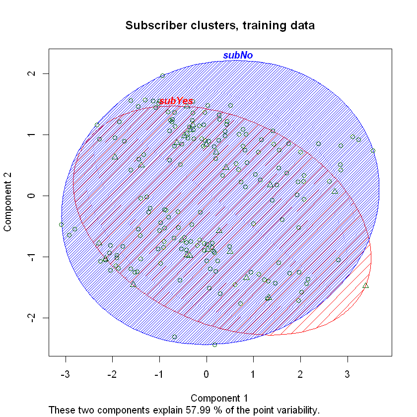

```r
clusplot(sub.df.train[, -6], sub.df.train$subscribe, color=TRUE, shade=TRUE, labels=4, lines=0, main="Subscriber clusters, training data")
```

The result in figure shows that the subscribers and non-subscribers are not well differentiated when plotted against principal components (which reflect almost 58% of the variance in the data). This suggests that the problem will be difficult!

```r
set.seed(11954)
(sub.rf <- randomForest(subscribe ∼ ., data=sub.df.train,ntree=3000))
```

```
Call:
 randomForest(formula = subscribe ~ ., data = sub.df.train, ntree = 3000)
               Type of random forest: classification
                     Number of trees: 3000
No. of variables tried at each split: 2

        OOB estimate of  error rate: 14.36%
Confusion matrix:
       subNo subYes class.error
subNo    167      3  0.01764706
subYes    25      0  1.00000000
```

Why? This demonstrates the class imbalance problem in machine learning. When one category dominates the data, it is very difficult to learn to predict other groups.

```r
set.seed(11954)
(sub.rf <- randomForest(subscribe ∼ ., data=sub.df.train, ntree=3000,sampsize=c(25, 25)) )
```

```
Call:
 randomForest(formula = subscribe ~ ., data = sub.df.train, ntree = 3000,      sampsize = c(25, 25))
               Type of random forest: classification
                     Number of trees: 3000
No. of variables tried at each split: 2

        OOB estimate of  error rate: 34.36%
Confusion matrix:
       subNo subYes class.error
subNo    120     50   0.2941176
subYes    17      8   0.6800000
```

Although our overall error rate is substantially higher at 34.36%, we are successfully predicting 32% (i.e., 1−0.68) of the subscribers in the OOB data, which is greatly improved over zero.

We use *predict()* to apply the RF model to the holdout data and examine the confusion matrix:

```r
sub.rf.sub <- predict(sub.rf, sub.df.test)
table(sub.rf.sub, sub.df.test$subscribe)
```

```
sub.rf.sub subNo subYes
    subNo     72      9
    subYes    18      6
```

Is the model predicting better than chance? We use adjustedRandIndex() to find that performance is modestly better than chance, and we confirm this with cohen.kappa() in the psych package, which provides confidence intervals:

```r
adjustedRandIndex(sub.rf.sub, sub.df.test$subscribe)
```

0.0971762910200967

```r
cohen.kappa(cbind(sub.rf.sub, sub.df.test$subscribe))
```

```
Call: cohen.kappa1(x = x, w = w, n.obs = n.obs, alpha = alpha, levels = levels)

Cohen Kappa and Weighted Kappa correlation coefficients and confidence boundaries
                  lower estimate upper
unweighted kappa -0.051     0.16  0.37
weighted kappa   -0.051     0.16  0.37

 Number of subjects = 105
```

With an adjusted Rand Index $= 0.10$ and Cohen’s kappa $= 0.16$ , the model identifies subscribers in the test data modestly better than chance.